# ДОМАШНЕЕ ЗАДАНИЕ 1. Дескриптивный анализ данных

### 3. Отобразите данные по индексу WGI за 2024 год в виде горизонтального столбчатого графика (`score`). Примерный вид графика приведен ниже

[figure not shown]

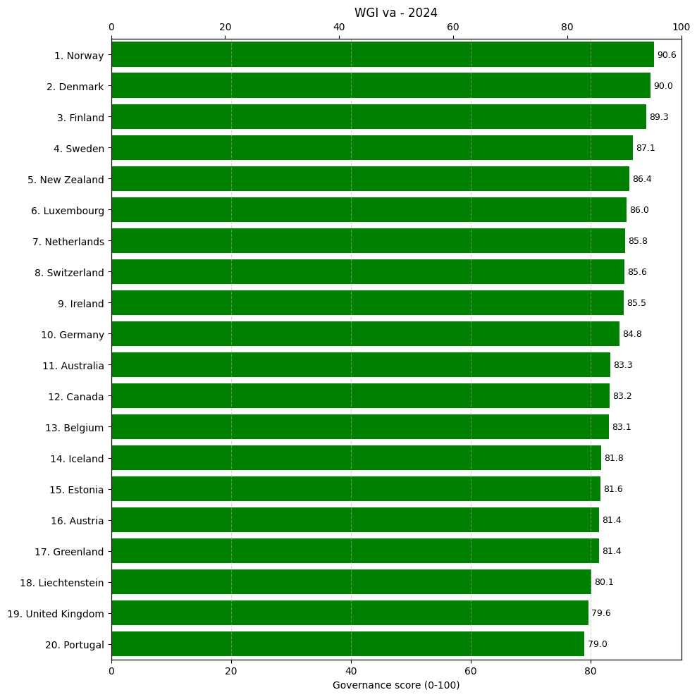

```python
import matplotlib.pyplot as plt

dimension_dropdown = widgets.Dropdown(
    options=dimensions,
    description='Dimension:',
    value=dimensions[0],
    style={'description_width': 'initial'},
    layout=widgets.Layout(width='400px')
)

year_dropdown = widgets.Dropdown(
    options=sorted(df_selected["Year"].unique(), reverse=True),
    description='Year:',
    value=2024,
    style={'description_width': 'initial'},
    layout=widgets.Layout(width='200px')
)

top_n_slider = widgets.IntSlider(
    value=20,
    min=5,
    max=100,
    step=5,
    description='Top N:',
    style={'description_width': 'initial'},
    layout=widgets.Layout(width='300px')
)

def plot_wgi(dimension, year, top_n):
    df_filtered = df_selected[
        (df_selected["Year"] == year) &
        (df_selected["Governance dimension"] == dimension)
    ].sort_values(by="Governance score (0-100)", ascending=False).head(top_n)

    df_filtered = df_filtered[::-1]

    plt.figure(figsize=(10, max(5, len(df_filtered)/2)))

    bars = plt.barh(range(len(df_filtered)), df_filtered["Governance score (0-100)"], color='green')

    plt.yticks(
        range(len(df_filtered)),
        [f"{len(df_filtered)-i}. {c}" for i, c in enumerate(df_filtered["Economy (name)"])]
    )

    ax = plt.gca()
    ax.set_ylim(-0.5, len(df_filtered)-0.5)

    ax_top = ax.twiny()
    ax_top.set_xlim(ax.get_xlim())
    ax_top.set_xticks(ax.get_xticks())
    ax_top.set_xticklabels([str(int(x)) for x in ax.get_xticks()])

    for i, v in enumerate(df_filtered["Governance score (0-100)"]):
        ax.text(v + 0.5, i, f"{v:.1f}", va='center', ha='left', fontsize=9, color='black')

    ax.set_xlabel("Governance score (0-100)")
    plt.title(f"WGI {dimension} - {year}")
    ax.grid(axis='x', linestyle='--', alpha=0.5)

    plt.tight_layout()
    plt.margins(y=0)

    plt.show()

if EXPORT_MODE:
    plot_wgi(
        dimension_dropdown.value,
        year_dropdown.value,
        top_n_slider.value
    )

else:
    out = widgets.interactive_output(plot_wgi, {
        'dimension': dimension_dropdown,
        'year': year_dropdown,
        'top_n': top_n_slider
    })

    display(widgets.HBox([dimension_dropdown, year_dropdown, top_n_slider]), out)
```

### 4. Сформируйте DataFrame из исходного для региона в соответствии с Вашим вариантом

- Вариант 1. Asia Pacific
- Вариант 2. Americas
- Вариант 3. Europe and Central Asia
- Вариант 4. Middle East and North Africa
- Вариант 5. Sub Saharan Africa

*Вариант 4. Middle East and North Africa*

```python
df_regions = pd.read_excel("./data/regions.xlsx")
```

```python
region_code = "MENA"
countries_codes_in_region = df_regions[df_regions["Region"] == region_code]["Code"].tolist()
```

### 5. Выведите данные DataFrame'a

```python
df_filtered_region = df_selected[df_selected["Economy (code)"].isin(countries_codes_in_region)]
print(df_filtered_region["Economy (name)"].unique())
df_filtered_region.head()
```

```
<ArrowStringArray>
['United Arab Emirates',              'Bahrain',              'Algeria',
     'Egypt, Arab Rep.',   'Iran, Islamic Rep.',                 'Iraq',
               'Israel',               'Jordan',               'Kuwait',
              'Lebanon',                'Libya',              'Morocco',
                 'Oman',                'Qatar',         'Saudi Arabia',
 'Syrian Arab Republic',              'Tunisia',          'Yemen, Rep.']
Length: 18, dtype: str
```

|  | Economy (name) | Economy (code) | Region | Year | Governance dimension | Governance score (0-100) | Governance estimate (approx. -2.5 to +2.5) | Standard error (gov. score) |
| --- | --- | --- | --- | --- | --- | --- | --- | --- |
| 4 | United Arab Emirates | ARE | Middle East & North Africa | 1996 | va | 42.006593 | -0.848031 | 3.395228 |
| 17 | Bahrain | BHR | Middle East & North Africa | 1996 | va | 37.750429 | -1.091205 | 3.395228 |
| 51 | Algeria | DZA | Middle East & North Africa | 1996 | va | 36.730597 | -1.149473 | 3.395228 |
| 53 | Egypt, Arab Rep. | EGY | Middle East & North Africa | 1996 | va | 36.771847 | -1.147116 | 3.395228 |
| 83 | Iran, Islamic Rep. | IRN | Middle East & North Africa | 1996 | va | 36.559318 | -1.159259 | 3.395228 |

### 6. Постройте графики индекса WGI за 1996-2024 для стран своего региона (`estimate`). Примерный вид графика приведен ниже

[figure not shown]

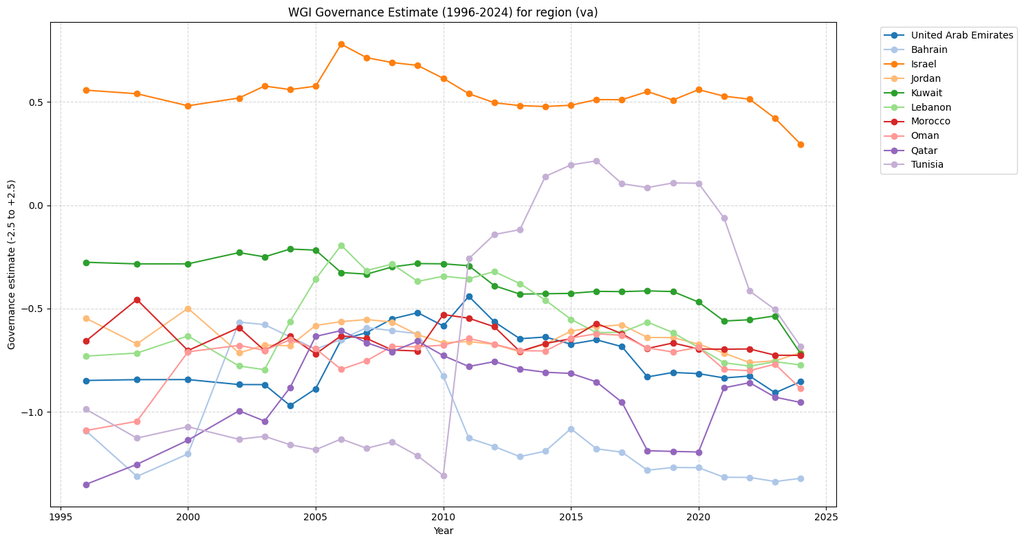

```python
dimensions = df_filtered_region["Governance dimension"].unique()

dimension_dropdown = widgets.Dropdown(
    options=dimensions,
    description='Dimension:',
    value=dimensions[0],
    style={'description_width': 'initial'},
    layout=widgets.Layout(width='400px')
)

top_n_slider = widgets.IntSlider(
    value=10,
    min=1,
    max=min(50, df_filtered_region["Economy (name)"].nunique()),
    step=1,
    description='Top N:',
    style={'description_width': 'initial'},
    layout=widgets.Layout(width='300px')
)

def plot_region_dimension(dimension, top_n):
    df_plot = df_filtered_region[
        df_filtered_region["Governance dimension"] == dimension
    ][["Economy (name)", "Year", "Governance estimate (approx. -2.5 to +2.5)"]]

    top_countries = (
        df_plot.groupby("Economy (name)")["Governance estimate (approx. -2.5 to +2.5)"]
        .max()
        .sort_values(ascending=False)
        .head(top_n)
        .index
    )
    df_plot = df_plot[df_plot["Economy (name)"].isin(top_countries)]

    if USE_PLOTLY:
        fig = px.line(
            df_plot,
            x="Year",
            y="Governance estimate (approx. -2.5 to +2.5)",
            color="Economy (name)",
            markers=True,
            hover_data={
                "Economy (name)": True,
                "Year": True,
                "Governance estimate (approx. -2.5 to +2.5)": ':.2f'
            }
        )

        fig.update_layout(
            title=f"WGI Governance Estimate (1996-2024) for region ({dimension})",
            xaxis_title="Year",
            yaxis_title="Governance estimate (-2.5 to +2.5)",
            legend_title="Country",
            template="plotly_white"
        )

        fig.show()

    else:
        plt.figure(figsize=(15, 8))

        countries = df_plot["Economy (name)"].unique()
        base_colors = plt.cm.tab20.colors
        colors = [base_colors[i % 20] for i in range(len(countries))]

        for i, country in enumerate(countries):
            df_country = df_plot[df_plot["Economy (name)"] == country].sort_values("Year")

            plt.plot(
                df_country["Year"],
                df_country["Governance estimate (approx. -2.5 to +2.5)"],
                marker='o',
                linestyle='-',
                label=country,
                color=colors[i]
            )

        plt.xlabel("Year")
        plt.ylabel("Governance estimate (-2.5 to +2.5)")
        plt.title(f"WGI Governance Estimate (1996-2024) for region ({dimension})")

        plt.grid(True, linestyle='--', alpha=0.5)
        plt.legend(bbox_to_anchor=(1.05, 1), loc='upper left')

        plt.tight_layout()
        plt.show()


if EXPORT_MODE:
    plot_region_dimension(
        dimension_dropdown.value,
        top_n_slider.value
    )

else:
    out = widgets.interactive_output(plot_region_dimension, {
        'dimension': dimension_dropdown,
        'top_n': top_n_slider
    })

    display(widgets.HBox([dimension_dropdown, top_n_slider]), out)
```

### 7. Найдите страны с наибольшим и наименьшим значением WGI Вашего варианта региона за 2024 год (`estimate`)

```
⚠️ **Замечание.** У нескольких стран может быть одна и та же позиция в рейтинге из-за одинаковых значений индекса
```

### 8. Определите средние значения региона за каждый год в период с 1996 по 2024 (`estimate`)

```python
dimensions = df_filtered_region["Governance dimension"].unique()
years = sorted(df_filtered_region["Year"].unique(), reverse=True)

dimension_dropdown = widgets.Dropdown(
    options=dimensions,
    description='Dimension:',
    value=dimensions[0],
    style={'description_width': 'initial'},
    layout=widgets.Layout(width='400px')
)

year_dropdown = widgets.Dropdown(
    options=years,
    description='Year:',
    value=2024,
    style={'description_width': 'initial'},
    layout=widgets.Layout(width='200px')
)

def compute_wgi_stats(dimension, year):
    df_dim = df_filtered_region[
        df_filtered_region["Governance dimension"] == dimension
    ]

    df_year = df_dim[
        df_dim["Year"] == year
    ][["Economy (name)", "Governance estimate (approx. -2.5 to +2.5)"]]

    max_value = df_year["Governance estimate (approx. -2.5 to +2.5)"].max()
    min_value = df_year["Governance estimate (approx. -2.5 to +2.5)"].min()

    max_countries = df_year[
        df_year["Governance estimate (approx. -2.5 to +2.5)"] == max_value
    ]["Economy (name)"].tolist()

    min_countries = df_year[
        df_year["Governance estimate (approx. -2.5 to +2.5)"] == min_value
    ]["Economy (name)"].tolist()

    df_region_estimate = df_dim[["Year", "Governance estimate (approx. -2.5 to +2.5)"]]
    region_mean_per_year = (
        df_region_estimate
        .groupby("Year")
        .mean()
        .reset_index()
        .rename(columns={
            "Governance estimate (approx. -2.5 to +2.5)": "Regional Mean Estimate"
        })
    )

    return max_value, min_value, max_countries, min_countries, region_mean_per_year


def show_wgi_stats(dimension, year):
    max_val, min_val, max_c, min_c, df_mean = compute_wgi_stats(dimension, year)

    print(f"Страны с наибольшим WGI за {year} (Estimate = {max_val:.2f}): {', '.join(max_c)}")
    print(f"Страны с наименьшим WGI за {year} (Estimate = {min_val:.2f}): {', '.join(min_c)}\n")

    display(df_mean)


if EXPORT_MODE:
    show_wgi_stats(
        dimension_dropdown.value,
        year_dropdown.value
    )

else:
    out = widgets.interactive_output(show_wgi_stats, {
        'dimension': dimension_dropdown,
        'year': year_dropdown
    })

    display(widgets.HBox([dimension_dropdown, year_dropdown]), out)
```

```
Страны с наибольшим WGI за 2024 (Estimate = 0.30): Israel
Страны с наименьшим WGI за 2024 (Estimate = -1.85): Syrian Arab Republic
```

|  | Year | Regional Mean Estimate |
| --- | --- | --- |
| 0 | 1996 | -1.045856 |
| 1 | 1998 | -1.080369 |
| 2 | 2000 | -1.049152 |
| 3 | 2002 | -0.995664 |
| 4 | 2003 | -0.983702 |
| 5 | 2004 | -0.917957 |
| 6 | 2005 | -0.870692 |
| 7 | 2006 | -0.824171 |
| 8 | 2007 | -0.834705 |
| 9 | 2008 | -0.841918 |
| 10 | 2009 | -0.858823 |
| 11 | 2010 | -0.896225 |
| 12 | 2011 | -0.846712 |
| 13 | 2012 | -0.809041 |
| 14 | 2013 | -0.852651 |
| 15 | 2014 | -0.848534 |
| 16 | 2015 | -0.846341 |
| 17 | 2016 | -0.875042 |
| 18 | 2017 | -0.895195 |
| 19 | 2018 | -0.941168 |
| 20 | 2019 | -0.941538 |
| 21 | 2020 | -0.954668 |
| 22 | 2021 | -0.984874 |
| 23 | 2022 | -1.010110 |
| 24 | 2023 | -1.029165 |
| 25 | 2024 | -1.054704 |

### 9. Постройте графики индекса WGI за 1996-2024 для стран своего региона и выделите страны с наибольшим и наименьшим значением WGI за 2024 год, а также отобразите среднее значение по региону и РФ. Примерный вид графика приведен ниже

[figure not shown]

График построен по параметру `Governance score (0-100)`, для параметра `Governance estimate (approx. -2.5 to +2.5)` результат +- аналогичен.

[figure not shown]

```python
dimensions = df_filtered_region["Governance dimension"].unique()

dimension_dropdown = widgets.Dropdown(
    options=dimensions,
    description='Dimension:',
    value=dimensions[0],
    style={'description_width': 'initial'},
    layout=widgets.Layout(width='400px')
)

top_n_slider = widgets.IntSlider(
    value=10,
    min=1,
    max=min(50, df_filtered_region["Economy (name)"].nunique()),
    step=1,
    description='Top N:',
    style={'description_width': 'initial'},
    layout=widgets.Layout(width='300px')
)

def plot_region_dimension(dimension, top_n):
    df_plot = df_filtered_region[
        df_filtered_region["Governance dimension"] == dimension
    ][["Economy (name)", "Year", "Governance score (0-100)"]]

    top_countries = (
        df_plot.groupby("Economy (name)")["Governance score (0-100)"]
        .max().sort_values(ascending=False).head(top_n).index
    )
    df_plot = df_plot[df_plot["Economy (name)"].isin(top_countries)]

    df_2024 = df_plot[df_plot["Year"] == 2024]
    max_val = df_2024["Governance score (0-100)"].max()
    min_val = df_2024["Governance score (0-100)"].min()

    max_countries = df_2024[df_2024["Governance score (0-100)"] == max_val]["Economy (name)"].tolist()
    min_countries = df_2024[df_2024["Governance score (0-100)"] == min_val]["Economy (name)"].tolist()

    if USE_PLOTLY:
        fig = go.Figure()

        gray_countries = [
            c for c in df_plot["Economy (name)"].unique() if c not in max_countries + min_countries
        ]

        for country in gray_countries:
            df_country = df_plot[df_plot["Economy (name)"] == country].sort_values("Year")
            fig.add_trace(go.Scatter(
                x=df_country["Year"],
                y=df_country["Governance score (0-100)"],
                mode='lines+markers',
                line=dict(color='lightgray'),
                marker=dict(color='lightgray'),
                name=country,
                showlegend=False
            ))

        for country in max_countries:
            df_country = df_plot[df_plot["Economy (name)"] == country].sort_values("Year")
            fig.add_trace(go.Scatter(
                x=df_country["Year"],
                y=df_country["Governance score (0-100)"],
                mode='lines+markers',
                line=dict(width=3, color='green'),
                name=f"{country} (max 2024)"
            ))

        for country in min_countries:
            df_country = df_plot[df_plot["Economy (name)"] == country].sort_values("Year")
            fig.add_trace(go.Scatter(
                x=df_country["Year"],
                y=df_country["Governance score (0-100)"],
                mode='lines+markers',
                line=dict(width=3, color='red'),
                name=f"{country} (min 2024)"
            ))

        df_mean = df_plot.groupby("Year")["Governance score (0-100)"].mean().reset_index()
        fig.add_trace(go.Scatter(
            x=df_mean["Year"],
            y=df_mean["Governance score (0-100)"],
            mode='lines+markers',
            line=dict(width=3, color='yellow'),
            name="Regional Mean"
        ))

        df_russia = df_selected[
            (df_selected["Economy (name)"] == "Russian Federation") &
            (df_selected["Governance dimension"] == dimension)
        ][["Year", "Governance score (0-100)"]].sort_values("Year")

        if not df_russia.empty:
            fig.add_trace(go.Scatter(
                x=df_russia["Year"],
                y=df_russia["Governance score (0-100)"],
                mode='lines+markers',
                line=dict(width=3, color='blue'),
                name="Russia"
            ))

        fig.update_layout(
            title=f"WGI Governance score (1996-2024) for region ({dimension})",
            xaxis_title="Year",
            yaxis_title="Governance score (0-100)",
            template="plotly_white"
        )

        fig.show()

    else:
        plt.figure(figsize=(15, 8))

        gray_countries = [
            c for c in df_plot["Economy (name)"].unique() if c not in max_countries + min_countries
        ]

        for country in gray_countries:
            df_country = df_plot[df_plot["Economy (name)"] == country].sort_values("Year")
            plt.plot(
                df_country["Year"],
                df_country["Governance score (0-100)"],
                color='lightgray',
                marker='o',
                linewidth=1,
                alpha=0.7
            )

        for country in max_countries:
            df_country = df_plot[df_plot["Economy (name)"] == country].sort_values("Year")
            plt.plot(
                df_country["Year"],
                df_country["Governance score (0-100)"],
                color='green',
                marker='o',
                linewidth=3,
                label=f"{country} (max 2024)"
            )

        for country in min_countries:
            df_country = df_plot[df_plot["Economy (name)"] == country].sort_values("Year")
            plt.plot(
                df_country["Year"],
                df_country["Governance score (0-100)"],
                color='red',
                marker='o',
                linewidth=3,
                label=f"{country} (min 2024)"
            )

        df_mean = df_plot.groupby("Year")["Governance score (0-100)"].mean().reset_index()
        plt.plot(
            df_mean["Year"],
            df_mean["Governance score (0-100)"],
            color='orange',
            linewidth=3,
            marker='o',
            label="Regional Mean"
        )

        df_russia = df_selected[
            (df_selected["Economy (name)"] == "Russian Federation") &
            (df_selected["Governance dimension"] == dimension)
        ][["Year", "Governance score (0-100)"]].sort_values("Year")

        if not df_russia.empty:
            plt.plot(
                df_russia["Year"],
                df_russia["Governance score (0-100)"],
                color='blue',
                linewidth=3,
                marker='o',
                label="Russia"
            )

        plt.title(f"WGI Governance score (1996-2024) for region ({dimension})")
        plt.xlabel("Year")
        plt.ylabel("Governance score (0-100)")
        plt.grid(True, linestyle='--', alpha=0.5)

        plt.legend(bbox_to_anchor=(1.05, 1), loc='upper left')
        plt.tight_layout()
        plt.show()

if EXPORT_MODE:
    plot_region_dimension(dimension_dropdown.value, top_n_slider.value)
else:
    out = widgets.interactive_output(plot_region_dimension, {
        'dimension': dimension_dropdown,
        'top_n': top_n_slider
    })
    display(widgets.HBox([dimension_dropdown, top_n_slider]), out)
```

### 10. Определите, как изменилось значение показателя `score` с 1996 по 2024 (`score`)

Изменение показателя `score` представлено выше на графике. Также сравнение WGI 1996 с WGI 2024 приведено ниже в таблице.

### 11. Выведите таблицу для **Вашего варианта** (WGI - `score`)

|  | Регион | Страна | WGI 1996 | WGI 2024 | Изменение (см. пункт 10) |
| --- | --- | --- | --- | --- | --- |
| mean_2024 | - | - | - | - | - |
| max_2024 | - | - | - | - | - |
| min_2024 | - | - | - | - | - |
| Russia_2024 | - | - | - | - | - |

```python
dimensions = df_selected["Governance dimension"].unique()

dimension_dropdown = widgets.Dropdown(
    options=dimensions,
    description='Dimension:',
    value=dimensions[0],
    style={'description_width': 'initial'},
    layout=widgets.Layout(width='400px')
)

def update_summary_region(dimension):
    df_region_score = df_filtered_region[df_filtered_region["Governance dimension"] == dimension][
        ["Economy (name)", "Region", "Year", "Governance score (0-100)"]
    ]

    df_russia = df_selected[
        (df_selected["Economy (name)"] == "Russian Federation") &
        (df_selected["Governance dimension"] == dimension)
    ][["Economy (name)", "Region", "Year", "Governance score (0-100)"]]

    df_score = pd.concat([df_region_score, df_russia], ignore_index=True)

    df_1996 = df_score[df_score["Year"] == 1996][[
        "Economy (name)",
        "Region",
        "Governance score (0-100)"]
    ].rename(
        columns={"Governance score (0-100)": "WGI 1996"}
    )
    df_2024 = df_score[df_score["Year"] == 2024][[
        "Economy (name)",
        "Region",
        "Governance score (0-100)"]
    ].rename(
        columns={"Governance score (0-100)": "WGI 2024"}
    )

    df_combined = pd.merge(df_1996, df_2024, on=["Economy (name)", "Region"], how="outer")
    df_combined["Изменение (см. пункт 10)"] = df_combined["WGI 2024"] - df_combined["WGI 1996"]

    rows = []

    mean_1996 = df_region_score[df_region_score["Year"] == 1996]["Governance score (0-100)"].mean()
    mean_2024 = df_region_score[df_region_score["Year"] == 2024]["Governance score (0-100)"].mean()
    rows.append({
        "": "mean",
        "Регион": "-",
        "Страна": "-",
        "WGI 1996": mean_1996,
        "WGI 2024": mean_2024,
        "Изменение (см. пункт 10)": mean_2024 - mean_1996
    })

    max_val = df_region_score[df_region_score["Year"] == 2024]["Governance score (0-100)"].max()
    max_rows = df_region_score[
        (df_region_score["Year"] == 2024) &
        (df_region_score["Governance score (0-100)"] == max_val)
    ]
    for _, r in max_rows.iterrows():
        row_1996 = df_combined[
            df_combined["Economy (name)"] == r["Economy (name)"]
        ]["WGI 1996"].values[0]
        rows.append({
            "": "max",
            "Регион": r["Region"],
            "Страна": r["Economy (name)"],
            "WGI 1996": row_1996,
            "WGI 2024": r["Governance score (0-100)"],
            "Изменение (см. пункт 10)": r["Governance score (0-100)"] - row_1996
        })

    min_val = df_region_score[df_region_score["Year"] == 2024]["Governance score (0-100)"].min()
    min_rows = df_region_score[
        (df_region_score["Year"] == 2024) &
        (df_region_score["Governance score (0-100)"] == min_val)
    ]
    for _, r in min_rows.iterrows():
        row_1996 = df_combined[
            df_combined["Economy (name)"] == r["Economy (name)"]
        ]["WGI 1996"].values[0]
        rows.append({
            "": "min",
            "Регион": r["Region"],
            "Страна": r["Economy (name)"],
            "WGI 1996": row_1996,
            "WGI 2024": r["Governance score (0-100)"],
            "Изменение (см. пункт 10)": r["Governance score (0-100)"] - row_1996
        })

    if not df_russia.empty:
        r = df_russia[df_russia["Year"] == 2024].iloc[0]
        row_1996 = df_combined[df_combined["Economy (name)"] == r["Economy (name)"]]["WGI 1996"].values[0]
        rows.append({
            "": "Russia",
            "Регион": r["Region"],
            "Страна": "Russia",
            "WGI 1996": row_1996,
            "WGI 2024": r["Governance score (0-100)"],
            "Изменение (см. пункт 10)": r["Governance score (0-100)"] - row_1996
        })

    df_summary = pd.DataFrame(rows)
    display(df_summary)

if EXPORT_MODE:
    update_summary_region(dimension_dropdown.value)
else:
    out = widgets.interactive_output(update_summary_region, {'dimension': dimension_dropdown})
    display(dimension_dropdown, out)
```

|  |  | Регион | Страна | WGI 1996 | WGI 2024 | Изменение (см. пункт 10) |
| --- | --- | --- | --- | --- | --- | --- |
| 0 | mean | - | - | 38.544163 | 38.389295 | -0.154868 |
| 1 | max | Middle East & North Africa | Israel | 66.591641 | 62.015206 | -4.576435 |
| 2 | min | Middle East & North Africa | Syrian Arab Republic | 28.660460 | 24.517035 | -4.143425 |
| 3 | Russia | Europe & Central Asia | Russia | 49.747270 | 31.957630 | -17.789640 |

### 12. Отобразите диаграмму размаха (`boxplot`) индекса WGI за 2024 для всех стран и для каждого региона в отдельности (на одном графике) (`estimate`)

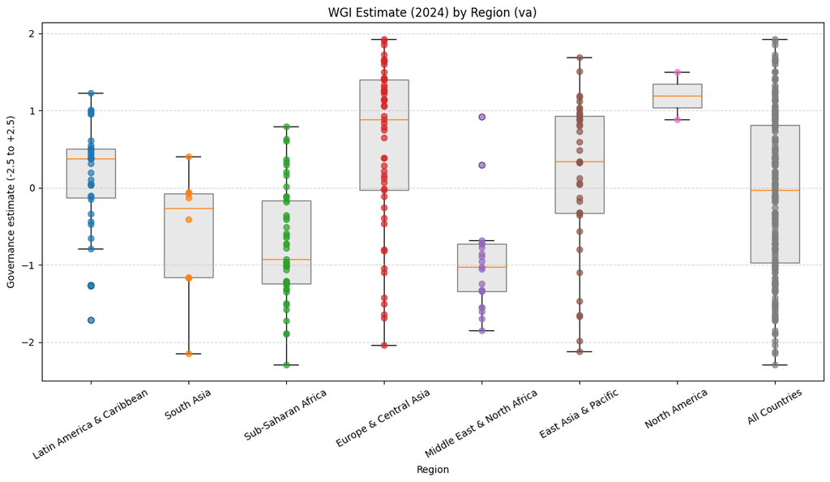

```python
dimensions = df_selected["Governance dimension"].unique()

dimension_dropdown = widgets.Dropdown(
    options=dimensions,
    description='Dimension:',
    value=dimensions[0],
    style={'description_width': 'initial'},
    layout=widgets.Layout(width='400px')
)

def plot_wgi_boxplot(dimension):
    df_plot = df_selected[
        (df_selected["Governance dimension"] == dimension) &
        (df_selected["Year"] == 2024)
    ][["Economy (name)", "Region", "Governance estimate (approx. -2.5 to +2.5)"]].copy()

    df_plot_all = df_plot.copy()
    df_plot_all["Region"] = "All Countries"

    df_box = pd.concat([df_plot, df_plot_all], ignore_index=True)

    if USE_PLOTLY:
        fig = px.box(
            df_box,
            x="Region",
            y="Governance estimate (approx. -2.5 to +2.5)",
            points="all",
            color="Region",
            hover_data={
                "Economy (name)": True,
                "Region": True,
                "Governance estimate (approx. -2.5 to +2.5)": ':.2f'
            },
            title=f"WGI Estimate (2024) by Region ({dimension})",
            labels={"Governance estimate (approx. -2.5 to +2.5)": "Governance estimate (-2.5 to +2.5)"},
            template="plotly_white"
        )

        fig.update_layout(showlegend=False)
        fig.show()

    else:
        plt.figure(figsize=(12, 7))

        regions = df_box["Region"].unique()
        data = []
        labels = []

        for region in regions:
            values = df_box[df_box["Region"] == region]["Governance estimate (approx. -2.5 to +2.5)"]
            data.append(values)
            labels.append(region)

        box = plt.boxplot(
            data,
            labels=labels,
            patch_artist=True,
            zorder=1
        )

        for patch in box['boxes']:
            patch.set_facecolor('lightgray')
            patch.set_alpha(0.5)

        for i, region in enumerate(regions):
            df_region = df_box[df_box["Region"] == region]
            y = df_region["Governance estimate (approx. -2.5 to +2.5)"]
            x = [i + 1] * len(y)

            plt.scatter(
                x, y,
                alpha=0.7,
                zorder=3
            )

        plt.title(f"WGI Estimate (2024) by Region ({dimension})")
        plt.xlabel("Region")
        plt.ylabel("Governance estimate (-2.5 to +2.5)")
        plt.grid(axis='y', linestyle='--', alpha=0.5)

        plt.xticks(rotation=30)
        plt.tight_layout()
        plt.show()

if EXPORT_MODE:
    plot_wgi_boxplot(dimension_dropdown.value)
else:
    out = widgets.interactive_output(plot_wgi_boxplot, {'dimension': dimension_dropdown})
    display(dimension_dropdown, out)
```

## Задача 2. Анализ рынка акций (4 балла)

### 1. Есть набор файлов, каждый из которых содержит данные по одной из акций. Все файлы имеют одинаковую структуру, в том числе наименование столбцов. Загрузите данные в один dataframe.

В качестве значений индекса dataframe'а необходимо указать значения столбца "Date". Название столбцов должные соответствовать названию акций (имя файла без .csv), а их значения - значениям цены закрытия (столбец "Close" в файлах .csv)

Набор данных

⚠️ **Замечание.** Наборы данные были загружены с сайта https://finance.yahoo.com/

⚠️ **Замечание.** Нужна только цена закрытия

```python
import os

folder_path = "./data/stock"

dfs = []

for file in os.listdir(folder_path):
    if file.endswith(".csv"):
        file_path = os.path.join(folder_path, file)

        stock_name = file.replace(".csv", "")

        df = pd.read_csv(file_path)

        df = df[["Date", "Close"]].copy()

        df["Date"] = pd.to_datetime(df["Date"])

        df.set_index("Date", inplace=True)

        df.rename(columns={"Close": stock_name}, inplace=True)

        dfs.append(df)

df_final = pd.concat(dfs, axis=1)

df_final.sort_index(inplace=True)

df_final.head()
```

| Date | AAPL | ABNB | ADBE | AMZN | CSCO | DBX | EBAY | GOOGL | GTLB | HPQ | ... | NVDA | ORCL | PINS | SHOP | SPOT | TCOM | TSLA | TWLO | UBER | XIACY |
| --- | --- | --- | --- | --- | --- | --- | --- | --- | --- | --- | --- | --- | --- | --- | --- | --- | --- | --- | --- | --- | --- |
| 2022-01-01 | 174.779999 | 153.970001 | 534.299988 | 149.573502 | 55.669998 | 24.750000 | 60.070000 | 135.303497 | 64.010002 | 36.730000 | ... | 244.860001 | 81.160004 | 29.559999 | NaN | 196.259995 | 26.610001 | 312.239990 | 206.119995 | 37.400002 | 10.7350 |
| 2022-02-01 | 165.119995 | 151.490005 | 467.679993 | 153.563004 | 55.770000 | 22.690001 | 54.590000 | 135.057007 | 58.270000 | 34.360001 | ... | 243.850006 | 75.970001 | 26.750000 | NaN | 156.190002 | 25.820000 | 290.143341 | 174.800003 | 36.029999 | 9.5500 |
| 2022-03-01 | 174.610001 | 171.759995 | 455.619995 | 162.997498 | 55.759998 | 23.250000 | 57.259998 | 139.067505 | 54.450001 | 36.299999 | ... | 272.859985 | 82.730003 | 24.610001 | NaN | 151.020004 | 23.120001 | 359.200012 | 164.809998 | 35.680000 | 8.7199 |
| 2022-04-01 | 157.649994 | 153.210007 | 395.950012 | 124.281502 | 48.980000 | 21.750000 | 51.919998 | 114.109497 | 47.930000 | 36.630001 | ... | 185.470001 | 73.400002 | 20.520000 | NaN | 101.650002 | 23.650000 | 290.253326 | 111.820000 | 31.480000 | 7.5400 |
| 2022-05-01 | 148.839996 | 120.870003 | 416.480011 | 120.209503 | 45.049999 | 20.840000 | 48.669998 | 113.762001 | 38.939999 | 38.840000 | ... | 186.720001 | 71.919998 | 19.650000 | NaN | 112.769997 | 22.059999 | 252.753326 | 105.169998 | 23.200001 | 7.6300 |

5 rows × 25 columns

### 2. Рассчитайте корреляционную матрицу для всех акций

Корреляционная матрица по ценам

```python
corr_matrix = df_final.corr()
corr_matrix
```

|  | AAPL | ABNB | ADBE | AMZN | CSCO | DBX | EBAY | GOOGL | GTLB | HPQ | ... | NVDA | ORCL | PINS | SHOP | SPOT | TCOM | TSLA | TWLO | UBER | XIACY |
| --- | --- | --- | --- | --- | --- | --- | --- | --- | --- | --- | --- | --- | --- | --- | --- | --- | --- | --- | --- | --- | --- |
| AAPL | 1.000000 | 0.617430 | 0.833129 | 0.665715 | 0.589552 | 0.740429 | 0.115591 | 0.806847 | 0.282373 | 0.067074 | ... | 0.633114 | 0.769309 | 0.640294 | 0.465147 | 0.687415 | 0.439363 | 0.248385 | 0.042914 | 0.661323 | 0.408747 |
| ABNB | 0.617430 | 1.000000 | 0.670509 | 0.830690 | 0.594365 | 0.332740 | 0.644140 | 0.780440 | 0.460602 | 0.390153 | ... | 0.649664 | 0.471504 | 0.554616 | 0.696599 | 0.753797 | 0.294269 | 0.353807 | 0.429915 | 0.680764 | 0.564475 |
| ADBE | 0.833129 | 0.670509 | 1.000000 | 0.819614 | 0.554172 | 0.816359 | 0.180354 | 0.915440 | 0.496556 | 0.081518 | ... | 0.802739 | 0.785432 | 0.804657 | 0.783919 | 0.863827 | 0.533298 | 0.071508 | 0.067604 | 0.834611 | 0.697612 |
| AMZN | 0.665715 | 0.830690 | 0.819614 | 1.000000 | 0.404820 | 0.478171 | 0.434078 | 0.912332 | 0.690644 | 0.235247 | ... | 0.765294 | 0.534556 | 0.666996 | 0.824934 | 0.875779 | 0.309545 | 0.302321 | 0.314869 | 0.796897 | 0.654564 |
| CSCO | 0.589552 | 0.594365 | 0.554172 | 0.404820 | 1.000000 | 0.496982 | 0.494938 | 0.600025 | 0.068856 | 0.214262 | ... | 0.320159 | 0.463955 | 0.384233 | -0.144612 | 0.424007 | 0.257188 | 0.253808 | 0.383777 | 0.326346 | 0.474311 |
| DBX | 0.740429 | 0.332740 | 0.816359 | 0.478171 | 0.496982 | 1.000000 | -0.157363 | 0.669228 | 0.402517 | -0.177013 | ... | 0.519374 | 0.667833 | 0.710191 | 0.424923 | 0.525305 | 0.423136 | 0.037233 | -0.113102 | 0.595928 | 0.382992 |
| EBAY | 0.115591 | 0.644140 | 0.180354 | 0.434078 | 0.494938 | -0.157363 | 1.000000 | 0.375794 | 0.251066 | 0.744560 | ... | 0.087027 | -0.070414 | -0.002757 | 0.338672 | 0.296858 | -0.149330 | 0.434899 | 0.753732 | 0.085736 | 0.535223 |
| GOOGL | 0.806847 | 0.780440 | 0.915440 | 0.912332 | 0.600025 | 0.669228 | 0.375794 | 1.000000 | 0.535473 | 0.263251 | ... | 0.715287 | 0.618983 | 0.640675 | 0.824313 | 0.821587 | 0.322718 | 0.326662 | 0.315410 | 0.737311 | 0.680658 |
| GTLB | 0.282373 | 0.460602 | 0.496556 | 0.690644 | 0.068856 | 0.402517 | 0.251066 | 0.535473 | 1.000000 | 0.094128 | ... | 0.404702 | 0.138574 | 0.525458 | 0.855342 | 0.540113 | 0.103614 | 0.260908 | 0.310273 | 0.521399 | 0.453669 |
| HPQ | 0.067074 | 0.390153 | 0.081518 | 0.235247 | 0.214262 | -0.177013 | 0.744560 | 0.263251 | 0.094128 | 1.000000 | ... | -0.160502 | -0.260316 | -0.285950 | 0.436406 | 0.005774 | -0.443806 | 0.568231 | 0.728572 | -0.180970 | 0.378627 |
| INTC | 0.507251 | 0.738241 | 0.713875 | 0.816519 | 0.420854 | 0.390625 | 0.580047 | 0.826042 | 0.535441 | 0.591406 | ... | 0.458281 | 0.239485 | 0.452144 | 0.809582 | 0.645555 | -0.014994 | 0.425236 | 0.585988 | 0.512572 | 0.791377 |
| META | 0.705358 | 0.723419 | 0.873388 | 0.830910 | 0.374998 | 0.552874 | 0.190361 | 0.808784 | 0.467641 | -0.035611 | ... | 0.961389 | 0.821696 | 0.822643 | 0.735282 | 0.973401 | 0.707029 | -0.144519 | -0.072886 | 0.954444 | 0.573429 |
| MSFT | 0.790691 | 0.679204 | 0.913842 | 0.838702 | 0.391476 | 0.648164 | 0.127010 | 0.845993 | 0.451366 | -0.034581 | ... | 0.935386 | 0.847046 | 0.837576 | 0.842193 | 0.949380 | 0.662193 | -0.117639 | -0.094023 | 0.939538 | 0.565831 |
| MU | 0.606787 | 0.842928 | 0.817961 | 0.906932 | 0.472688 | 0.440043 | 0.512637 | 0.867191 | 0.543109 | 0.308473 | ... | 0.796707 | 0.570765 | 0.717881 | 0.804352 | 0.902439 | 0.402677 | 0.079944 | 0.315313 | 0.820809 | 0.720374 |
| NFLX | 0.701937 | 0.646901 | 0.821314 | 0.735466 | 0.497727 | 0.635239 | 0.138580 | 0.717756 | 0.452625 | -0.203337 | ... | 0.910910 | 0.859397 | 0.930638 | 0.852517 | 0.920771 | 0.766681 | -0.251616 | -0.102302 | 0.937042 | 0.505430 |
| NVDA | 0.633114 | 0.649664 | 0.802739 | 0.765294 | 0.320159 | 0.519374 | 0.087027 | 0.715287 | 0.404702 | -0.160502 | ... | 1.000000 | 0.875089 | 0.815629 | 0.713391 | 0.925270 | 0.787859 | -0.277600 | -0.244797 | 0.969790 | 0.445645 |
| ORCL | 0.769309 | 0.471504 | 0.785432 | 0.534556 | 0.463955 | 0.667833 | -0.070414 | 0.618983 | 0.138574 | -0.260316 | ... | 0.875089 | 1.000000 | 0.747754 | 0.635736 | 0.763100 | 0.836340 | -0.310021 | -0.393536 | 0.832075 | 0.324511 |
| PINS | 0.640294 | 0.554616 | 0.804657 | 0.666996 | 0.384233 | 0.710191 | -0.002757 | 0.640675 | 0.525458 | -0.285950 | ... | 0.815629 | 0.747754 | 1.000000 | 0.846115 | 0.842858 | 0.705551 | -0.253055 | -0.141953 | 0.907751 | 0.524413 |
| SHOP | 0.465147 | 0.696599 | 0.783919 | 0.824934 | -0.144612 | 0.424923 | 0.338672 | 0.824313 | 0.855342 | 0.436406 | ... | 0.713391 | 0.635736 | 0.846115 | 1.000000 | 0.737909 | 0.592950 | 0.025575 | 0.657843 | 0.836565 | 0.519367 |
| SPOT | 0.687415 | 0.753797 | 0.863827 | 0.875779 | 0.424007 | 0.525305 | 0.296858 | 0.821587 | 0.540113 | 0.005774 | ... | 0.925270 | 0.763100 | 0.842858 | 0.737909 | 1.000000 | 0.640120 | -0.092332 | 0.059969 | 0.933308 | 0.647331 |
| TCOM | 0.439363 | 0.294269 | 0.533298 | 0.309545 | 0.257188 | 0.423136 | -0.149330 | 0.322718 | 0.103614 | -0.443806 | ... | 0.787859 | 0.836340 | 0.705551 | 0.592950 | 0.640120 | 1.000000 | -0.586854 | -0.562073 | 0.754442 | 0.237659 |
| TSLA | 0.248385 | 0.353807 | 0.071508 | 0.302321 | 0.253808 | 0.037233 | 0.434899 | 0.326662 | 0.260908 | 0.568231 | ... | -0.277600 | -0.310021 | -0.253055 | 0.025575 | -0.092332 | -0.586854 | 1.000000 | 0.703872 | -0.221155 | 0.184629 |
| TWLO | 0.042914 | 0.429915 | 0.067604 | 0.314869 | 0.383777 | -0.113102 | 0.753732 | 0.315410 | 0.310273 | 0.728572 | ... | -0.244797 | -0.393536 | -0.141953 | 0.657843 | 0.059969 | -0.562073 | 0.703872 | 1.000000 | -0.186828 | 0.447846 |
| UBER | 0.661323 | 0.680764 | 0.834611 | 0.796897 | 0.326346 | 0.595928 | 0.085736 | 0.737311 | 0.521399 | -0.180970 | ... | 0.969790 | 0.832075 | 0.907751 | 0.836565 | 0.933308 | 0.754442 | -0.221155 | -0.186828 | 1.000000 | 0.495835 |
| XIACY | 0.408747 | 0.564475 | 0.697612 | 0.654564 | 0.474311 | 0.382992 | 0.535223 | 0.680658 | 0.453669 | 0.378627 | ... | 0.445645 | 0.324511 | 0.524413 | 0.519367 | 0.647331 | 0.237659 | 0.184629 | 0.447846 | 0.495835 | 1.000000 |

25 rows × 25 columns

Корреляционная матрица по доходностям

```python
returns = df_final.pct_change()

corr_matrix_returns = returns.corr()
corr_matrix_returns
```

|  | AAPL | ABNB | ADBE | AMZN | CSCO | DBX | EBAY | GOOGL | GTLB | HPQ | ... | NVDA | ORCL | PINS | SHOP | SPOT | TCOM | TSLA | TWLO | UBER | XIACY |
| --- | --- | --- | --- | --- | --- | --- | --- | --- | --- | --- | --- | --- | --- | --- | --- | --- | --- | --- | --- | --- | --- |
| AAPL | 1.000000 | 0.647446 | 0.731185 | 0.733110 | 0.511391 | 0.477592 | 0.601010 | 0.646388 | 0.158643 | 0.614992 | ... | 0.628074 | 0.701751 | 0.503623 | 0.825391 | 0.590612 | -0.210709 | 0.688299 | 0.469787 | 0.557328 | 0.194591 |
| ABNB | 0.647446 | 1.000000 | 0.331655 | 0.602549 | 0.307032 | 0.182396 | 0.669479 | 0.404628 | 0.095758 | 0.453268 | ... | 0.559473 | 0.331598 | 0.400087 | 0.223743 | 0.497531 | -0.042676 | 0.697942 | 0.369599 | 0.690022 | 0.076747 |
| ADBE | 0.731185 | 0.331655 | 1.000000 | 0.547367 | 0.605236 | 0.674230 | 0.502995 | 0.694949 | 0.130822 | 0.654086 | ... | 0.610339 | 0.777190 | 0.520749 | 0.674881 | 0.579405 | -0.031395 | 0.294874 | 0.372659 | 0.336555 | 0.466746 |
| AMZN | 0.733110 | 0.602549 | 0.547367 | 1.000000 | 0.380183 | 0.308853 | 0.592936 | 0.750967 | 0.227888 | 0.348873 | ... | 0.733313 | 0.435940 | 0.431676 | 0.523197 | 0.791144 | -0.074029 | 0.700233 | 0.457946 | 0.599888 | 0.220979 |
| CSCO | 0.511391 | 0.307032 | 0.605236 | 0.380183 | 1.000000 | 0.511588 | 0.468107 | 0.541677 | 0.061787 | 0.308522 | ... | 0.594690 | 0.641939 | 0.387163 | -0.093108 | 0.313209 | -0.007016 | 0.262389 | 0.264862 | 0.284072 | 0.262082 |
| DBX | 0.477592 | 0.182396 | 0.674230 | 0.308853 | 0.511588 | 1.000000 | 0.183296 | 0.512300 | 0.379190 | 0.287810 | ... | 0.322448 | 0.510788 | 0.456518 | 0.469150 | 0.227043 | -0.043614 | 0.310343 | 0.345064 | 0.220770 | 0.118740 |
| EBAY | 0.601010 | 0.669479 | 0.502995 | 0.592936 | 0.468107 | 0.183296 | 1.000000 | 0.509710 | 0.005764 | 0.622829 | ... | 0.639051 | 0.552421 | 0.204845 | 0.154927 | 0.583853 | 0.147777 | 0.463589 | 0.160562 | 0.510545 | 0.425949 |
| GOOGL | 0.646388 | 0.404628 | 0.694949 | 0.750967 | 0.541677 | 0.512300 | 0.509710 | 1.000000 | 0.058544 | 0.433166 | ... | 0.751810 | 0.488373 | 0.357948 | 0.562995 | 0.593886 | 0.051070 | 0.486235 | 0.458295 | 0.475298 | 0.371537 |
| GTLB | 0.158643 | 0.095758 | 0.130822 | 0.227888 | 0.061787 | 0.379190 | 0.005764 | 0.058544 | 1.000000 | -0.171600 | ... | 0.051689 | 0.098257 | 0.346293 | 0.435462 | 0.177408 | 0.137351 | 0.289696 | 0.275446 | 0.358598 | 0.096607 |
| HPQ | 0.614992 | 0.453268 | 0.654086 | 0.348873 | 0.308522 | 0.287810 | 0.622829 | 0.433166 | -0.171600 | 1.000000 | ... | 0.553061 | 0.617909 | 0.202661 | 0.607759 | 0.348503 | 0.002815 | 0.325166 | 0.284635 | 0.294386 | 0.435135 |
| INTC | 0.628958 | 0.329686 | 0.737019 | 0.470793 | 0.459761 | 0.389236 | 0.484077 | 0.694259 | -0.094847 | 0.625513 | ... | 0.487397 | 0.477276 | 0.444817 | 0.638662 | 0.417588 | -0.018758 | 0.334876 | 0.382539 | 0.289181 | 0.505977 |
| META | 0.283086 | 0.412975 | 0.317912 | 0.420852 | 0.077907 | 0.044582 | 0.447566 | 0.436819 | 0.017672 | 0.312165 | ... | 0.580079 | 0.114413 | 0.261367 | 0.211172 | 0.638362 | 0.396307 | 0.325859 | 0.134371 | 0.497194 | 0.343973 |
| MSFT | 0.720323 | 0.344484 | 0.721935 | 0.681678 | 0.404698 | 0.406132 | 0.500548 | 0.717719 | -0.014709 | 0.541489 | ... | 0.736647 | 0.594392 | 0.371090 | 0.653298 | 0.653636 | 0.081639 | 0.352384 | 0.238659 | 0.432464 | 0.317056 |
| MU | 0.541623 | 0.518996 | 0.558090 | 0.623924 | 0.357455 | 0.168857 | 0.633857 | 0.695949 | -0.176071 | 0.634437 | ... | 0.654215 | 0.376223 | 0.315750 | 0.512906 | 0.572911 | -0.094730 | 0.330335 | 0.465882 | 0.471235 | 0.318449 |
| NFLX | 0.633480 | 0.387956 | 0.617213 | 0.705339 | 0.531426 | 0.464971 | 0.440985 | 0.589725 | 0.236143 | 0.324887 | ... | 0.679797 | 0.627368 | 0.651604 | 0.601383 | 0.700283 | -0.087188 | 0.399208 | 0.543012 | 0.482362 | 0.197793 |
| NVDA | 0.628074 | 0.559473 | 0.610339 | 0.733313 | 0.594690 | 0.322448 | 0.639051 | 0.751810 | 0.051689 | 0.553061 | ... | 1.000000 | 0.655950 | 0.308608 | 0.428897 | 0.744459 | 0.076090 | 0.551674 | 0.491558 | 0.598500 | 0.280670 |
| ORCL | 0.701751 | 0.331598 | 0.777190 | 0.435940 | 0.641939 | 0.510788 | 0.552421 | 0.488373 | 0.098257 | 0.617909 | ... | 0.655950 | 1.000000 | 0.282608 | 0.600479 | 0.451664 | -0.157168 | 0.301747 | 0.354822 | 0.352406 | 0.293053 |
| PINS | 0.503623 | 0.400087 | 0.520749 | 0.431676 | 0.387163 | 0.456518 | 0.204845 | 0.357948 | 0.346293 | 0.202661 | ... | 0.308608 | 0.282608 | 1.000000 | 0.557786 | 0.465641 | 0.097622 | 0.387943 | 0.402734 | 0.611334 | 0.305315 |
| SHOP | 0.825391 | 0.223743 | 0.674881 | 0.523197 | -0.093108 | 0.469150 | 0.154927 | 0.562995 | 0.435462 | 0.607759 | ... | 0.428897 | 0.600479 | 0.557786 | 1.000000 | 0.294527 | 0.112773 | 0.602749 | 0.725115 | 0.770335 | 0.065376 |
| SPOT | 0.590612 | 0.497531 | 0.579405 | 0.791144 | 0.313209 | 0.227043 | 0.583853 | 0.593886 | 0.177408 | 0.348503 | ... | 0.744459 | 0.451664 | 0.465641 | 0.294527 | 1.000000 | -0.031647 | 0.517175 | 0.488503 | 0.497056 | 0.341203 |
| TCOM | -0.210709 | -0.042676 | -0.031395 | -0.074029 | -0.007016 | -0.043614 | 0.147777 | 0.051070 | 0.137351 | 0.002815 | ... | 0.076090 | -0.157168 | 0.097622 | 0.112773 | -0.031647 | 1.000000 | -0.089154 | -0.380803 | 0.162683 | 0.497647 |
| TSLA | 0.688299 | 0.697942 | 0.294874 | 0.700233 | 0.262389 | 0.310343 | 0.463589 | 0.486235 | 0.289696 | 0.325166 | ... | 0.551674 | 0.301747 | 0.387943 | 0.602749 | 0.517175 | -0.089154 | 1.000000 | 0.545648 | 0.647058 | 0.116011 |
| TWLO | 0.469787 | 0.369599 | 0.372659 | 0.457946 | 0.264862 | 0.345064 | 0.160562 | 0.458295 | 0.275446 | 0.284635 | ... | 0.491558 | 0.354822 | 0.402734 | 0.725115 | 0.488503 | -0.380803 | 0.545648 | 1.000000 | 0.425021 | 0.092542 |
| UBER | 0.557328 | 0.690022 | 0.336555 | 0.599888 | 0.284072 | 0.220770 | 0.510545 | 0.475298 | 0.358598 | 0.294386 | ... | 0.598500 | 0.352406 | 0.611334 | 0.770335 | 0.497056 | 0.162683 | 0.647058 | 0.425021 | 1.000000 | 0.213188 |
| XIACY | 0.194591 | 0.076747 | 0.466746 | 0.220979 | 0.262082 | 0.118740 | 0.425949 | 0.371537 | 0.096607 | 0.435135 | ... | 0.280670 | 0.293053 | 0.305315 | 0.065376 | 0.341203 | 0.497647 | 0.116011 | 0.092542 | 0.213188 | 1.000000 |

25 rows × 25 columns

### 3. Отобразите корреляционную матрицу в виде диаграммы. Примерный вид графика приведен ниже

[figure not shown]

Диаграмма корреляционной матрицы по ценам

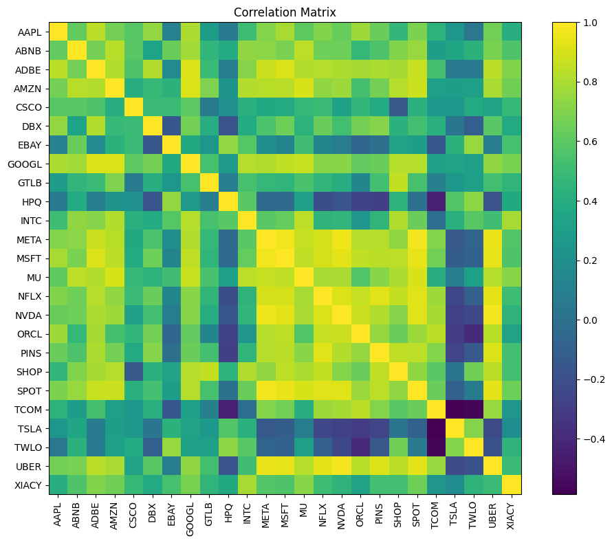

```python
plt.figure(figsize=(10, 8))
plt.imshow(corr_matrix, interpolation='nearest')
plt.colorbar()

plt.xticks(range(len(corr_matrix.columns)), corr_matrix.columns, rotation=90)
plt.yticks(range(len(corr_matrix.columns)), corr_matrix.columns)

plt.title("Correlation Matrix")
plt.tight_layout()
plt.show()
```

Диаграмма корреляционной матрицы по доходностям

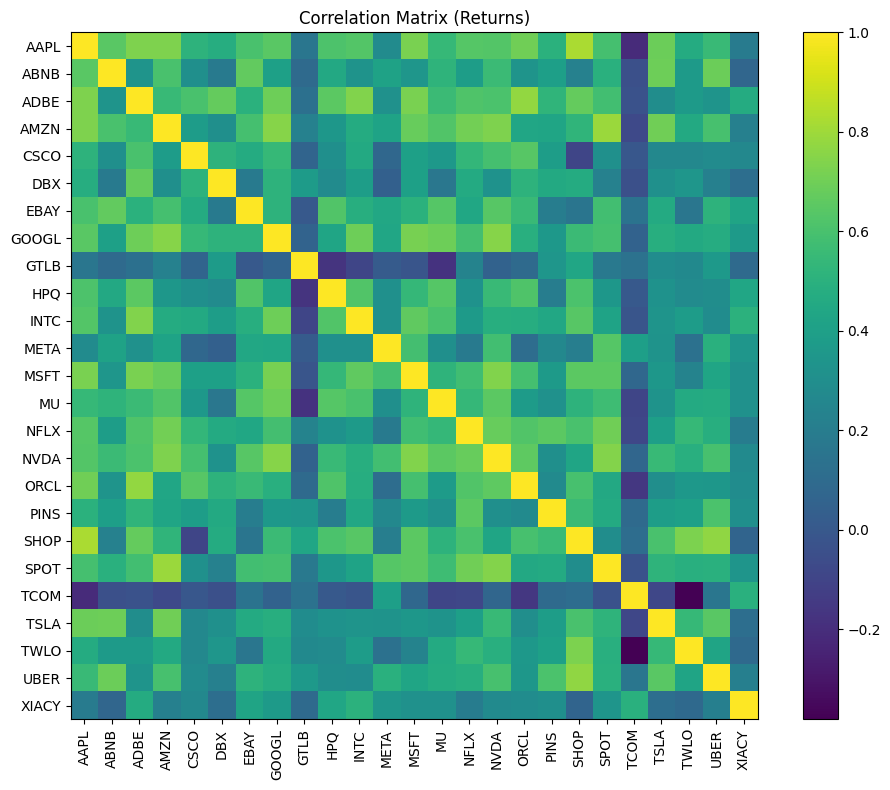

```python
plt.figure(figsize=(10, 8))
plt.imshow(corr_matrix_returns, interpolation='nearest')
plt.colorbar()

plt.xticks(range(len(corr_matrix_returns.columns)), corr_matrix_returns.columns, rotation=90)
plt.yticks(range(len(corr_matrix_returns.columns)), corr_matrix_returns.columns)

plt.title("Correlation Matrix (Returns)")
plt.tight_layout()
plt.show()
```

### 4. В соответствии с Вашим вариантом определите:

- акцию с максимальной положительной корреляцией (max)
- акцию с максимальной отрицательной корреляцией (min)
- акцию с минимальной корреляцией (которая больше всего соответствует отсутствию какой-либо корреляции (none)

Варианты

- **Вариант 1.** Microsoft (MSFT)
- **Вариант 2.** Netflix (NFLX)
- **Вариант 3.** Oracle (ORCL)
- **Вариант 4.** Uber (UBER)

***Вариант 3.** Oracle (ORCL)*

```python
returns = df_final.pct_change()

corr_with_orcl = returns.corr()["ORCL"].drop("ORCL")
display(corr_with_orcl)

max_stock = corr_with_orcl.idxmax()
max_value = corr_with_orcl.max()

min_stock = corr_with_orcl.idxmin()
min_value = corr_with_orcl.min()

none_stock = corr_with_orcl.abs().idxmin()
none_value = corr_with_orcl[none_stock]

print("Max correlation:", max_stock, max_value)
print("Min correlation:", min_stock, min_value)
print("No correlation:", none_stock, none_value)
```

```
AAPL     0.701751
ABNB     0.331598
ADBE     0.777190
AMZN     0.435940
CSCO     0.641939
DBX      0.510788
EBAY     0.552421
GOOGL    0.488373
GTLB     0.098257
HPQ      0.617909
INTC     0.477276
META     0.114413
MSFT     0.594392
MU       0.376223
NFLX     0.627368
NVDA     0.655950
PINS     0.282608
SHOP     0.600479
SPOT     0.451664
TCOM    -0.157168
TSLA     0.301747
TWLO     0.354822
UBER     0.352406
XIACY    0.293053
Name: ORCL, dtype: float64
```

```
Max correlation: ADBE 0.7771898746240583
Min correlation: TCOM -0.15716808338529162
No correlation: GTLB 0.09825743680975435
```

### 5. Постройте диаграммы разброса (Ваша компания - Компания с min), (Ваша компания - Компания с max), (Ваша компания - Компания с none)

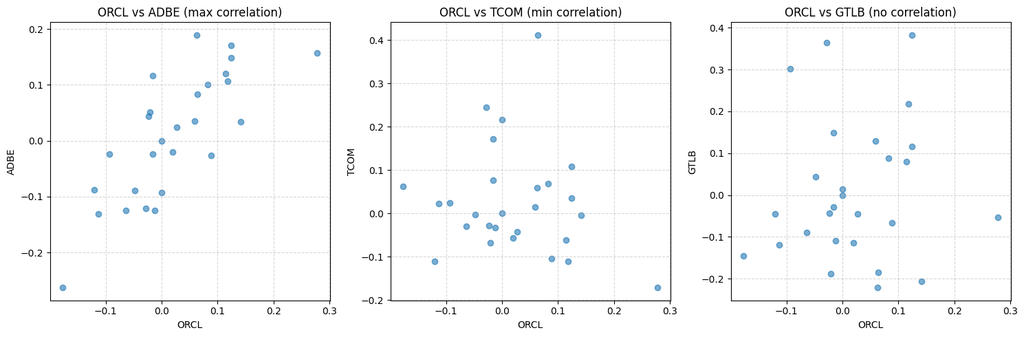

```python
pairs = [
    ("ORCL", max_stock, f"ORCL vs {max_stock} (max correlation)"),
    ("ORCL", min_stock, f"ORCL vs {min_stock} (min correlation)"),
    ("ORCL", none_stock, f"ORCL vs {none_stock} (no correlation)")
]

plt.figure(figsize=(15, 5))

for i, (stock1, stock2, title) in enumerate(pairs, 1):
    plt.subplot(1, 3, i)
    plt.scatter(returns[stock1], returns[stock2], alpha=0.6)
    plt.xlabel(stock1)
    plt.ylabel(stock2)
    plt.title(title)
    plt.grid(True, linestyle='--', alpha=0.5)

plt.tight_layout()
plt.show()
```

### 6. Рассчитайте среднюю цену акций для каждого месяца (исходные данные взяты с интервалом в месяц)

```python
df_final.index = pd.to_datetime(df_final.index)

monthly_mean = df_final.resample('ME').mean()

monthly_mean_all_stocks = monthly_mean.mean(axis=1)

monthly_mean["Average_All_Stocks"] = monthly_mean_all_stocks

display(monthly_mean_all_stocks.head())
```

```
Date
2022-01-31    154.857167
2022-02-28    140.774723
2022-03-31    145.272287
2022-04-30    115.763514
2022-05-31    112.316034
Freq: ME, dtype: float64
```

[figure not shown]

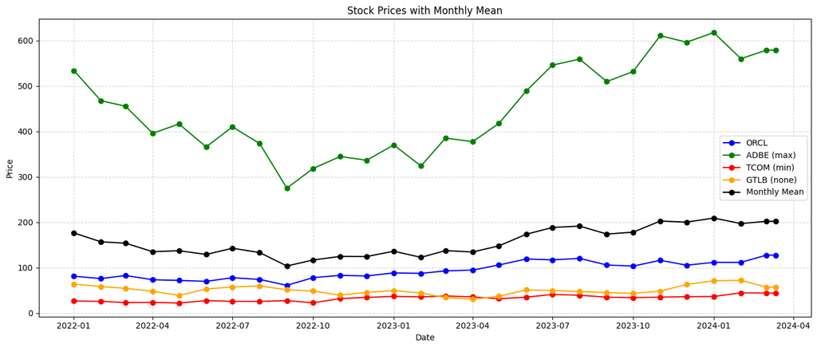

```python
# Акции из пункта 4
my_stock = "ORCL"
max_stock = "ADBE"
min_stock = "TCOM"
none_stock = "GTLB"

df_plot = df_final[[my_stock, max_stock, min_stock, none_stock]].copy()
df_plot["Monthly Mean"] = df_plot.mean(axis=1)

colors = {
    my_stock: "blue",
    max_stock: "green",
    min_stock: "red",
    none_stock: "orange",
    "Monthly Mean": "black"
}

legend_labels = {
    my_stock: my_stock,
    max_stock: f"{max_stock} (max)",
    min_stock: f"{min_stock} (min)",
    none_stock: f"{none_stock} (none)",
    "Monthly Mean": "Monthly Mean"
}

if USE_PLOTLY:
    fig = go.Figure()

    for col in df_plot.columns:
        fig.add_trace(go.Scatter(
            x=df_plot.index,
            y=df_plot[col],
            mode='lines+markers',
            line=dict(color=colors[col], width=2),
            marker=dict(size=6),
            name=legend_labels[col],
            hovertemplate='<b>%{text}</b><br>Date: %{x}<br>Price: %{y:.2f}',
            text=[col]*len(df_plot)
        ))

    fig.update_layout(
        title="Stock Prices with Monthly Mean",
        xaxis_title="Date",
        yaxis_title="Price",
        template="plotly_white",
        hovermode="closest"
    )
    fig.show()

else:
    plt.figure(figsize=(14, 6))
    for col in df_plot.columns:
        plt.plot(
            df_plot.index,
            df_plot[col],
            marker='o',
            linestyle='-',
            label=legend_labels[col],
            color=colors[col]
        )

    plt.xlabel("Date")
    plt.ylabel("Price")
    plt.title("Stock Prices with Monthly Mean")
    plt.grid(True, linestyle='--', alpha=0.5)
    plt.legend()
    plt.tight_layout()
    plt.show()
```